# C1 Activity Models - Longitudinal Models of the MIECHV Effectiveness and Statewide Trends

OUHSC MIECHV External Evaluation Team

This report covers the longitudinal models of the MIECHV effectiveness and of statewide trends. It is relevant to Aim 1C (“Evaluate the frequency of referrals coming into EBHV agencies”), Aim 3A (“Continually evaluate the flow of clients served per county”), Aim 3D (“Evaluate effectiveness of new engagement enhancement strategies”), and Aim 5C (“Implement and evaluate system of quality improvements and controls”) of [HRSA/ACF D89MC23154](http://ouhscbbmc.github.io/MReportingPublic/research-2011a.html) Investigation.

The processes for gathering and reshaping the C1 data was described in [C1 Activity Methods](http://ouhscbbmc.github.io/MReportingPublic/reports/c1-activity-methods-description.pdf).

# 1 Milestones

One of this investigation’s goals is to assess if C1 performance changes following significant events in Oklahoma’s home visiting programs. The following dates are of particular interest. A more detailed is found on our project’s [interactive timeline](http://ouhscbbmc.github.io/MReportingPublic/reports/Aim1B.html).

|  | Start Date | Stop Date | Description |
| --- | --- | --- | --- |
| Community Connector | May 01, 2012 | Present | Community Connector,Community Connector contracts start. (Tulsa & Oklahoma Counties in May 2012. Garfield, Kay, & Muskogee in October 2014.) |
| Community Connector 1 | May 01, 2012 | Present | Community Connector contracts start in Tulsa and Oklahoma Counties. |
| MIECHV | Jun 15, 2012 | Present | Program funds are spent in the counties. |
| MIECHV Phase 1 | Jun 15, 2012 | Dec 31, 2013 | Program funds start being spent in the counties. |
| MIECHV Phase 2 | Jan 01, 2014 | Present | Program funds continue being spent in the counties. |
| Ad Wave 1 | Apr 01, 2014 | Oct 31, 2014 | parentPRO ad campaign in summer and early fall. |
| PHI Sharing | May 23, 2014 | Present | Community Connectors can share PHI more efficiently with parentPRO. |
| Community Connector 2 | Oct 01, 2014 | Present | Community Connector contracts are awarded to Garfield, Kay, and Muskogee Counties. |
| parentPRO Website | Apr 02, 2015 | Present | The state’s umbrella website is deployed. |
| Ad Wave 2 | May 01, 2015 | Jun 30, 2015 | parentPRO ad campaign in late May and some in June. |

```
             EraWebsite
EraPhiSharing FALSE TRUE
        FALSE  1440   98
        TRUE     60   42
```

```
             HasConnector
EraPhiSharing FALSE TRUE
        FALSE  1488   50
        TRUE     31   71
```

```
          HasConnector
EraWebsite FALSE TRUE
     FALSE  1412   88
     TRUE    107   33
```

# 2 Modeling and Graphical Analysis

The outcomes of interest involve the referrals, enrollments, and visits of a C1 region. The MIECHV treatment is operationalized in two ways. In Model 1, a county’s treatment effect reflects the time period when it was *under contract* with OSDH; the corresponding coefficients are 1a-1e. In Model 2, the treatment effect reflects county *had at least one MIECHV-funded nurse on staff*; the corresponding coefficients are 2a-2e. For Models 1 and 2, the “MIECHV Era” is divided into two phases (the first 19 months and the next 24). Models 3 through 7 examine specific events related to the service, and keep the MIECHV Era as a single uniform period.

A two-level Poisson link is used in each model; the outcome at each month is nested within region. The Poisson offset is the region’s number of infants in need, which helped make the regions’ estimates more comparable. Level 1 estimates an intercept and a lag-3 autocorrelation for each region. Level 2 contains two classes of variables: the first attempts to partial out variability unrelated to MIECHV events, while the second addresses the investigation’s hypotheses. The first class estimates the overall level for each quarter year (to remove seasonal and secular trends) and a lag-3 autocorrelation (to control for longitudinal dependencies). The second class estimates a coefficient for the following five comparisons.

**MIECHV Contracted**

- Model 1: *MIECHV Contracted*: This indicator variable reflects the months each region had at least one MIECHV county under contract. The two formula grant counties (ie, Kay and Garfield) started in May 2011, while the four competition grant counties (ie, Comanche, Muskogee, Oklahoma, and Tulsa) started in October 2011. Coefficients *a*-*e* are reported for Model 1.

**MIECHV Staffed**

- Model 2: *MIECHV Nurses Staffed*: Some counties hired MIECHV-funded nurses in April 2012, while some could not fill it reliably until the summer of 2014. The model uses the `MiechvStaffed` variable, which is 1 during any month the region has at least one MIECHV-funded nurse, and 0 otherwise. Coefficients *a*-*e* are reported for Model 2.

**Isolated Events**

Additionally, a model was run for each of the five events to estimate it’s correspondence with each outcome. The change associated with the event is the only coefficient listed in the main text. Although the other coefficients in the event models differ from each other and the two-phase model, they are similar enough to exclude in the main text. Comprehensive model output is available in the appendix and online. A model was run for each of the following events:

- Model 3: *ParentPRO Community Connector in a county*. The two urban regions started in May 2012, while the remaining four regions started 2 years later in the fall of 2014. The model accommodates the start date of each region.
- Model 4: *First marketing wave*. The model accounts for the seven months of ParentPRO advertisements in 2014 for the six MIECHV regions. Although residents in non-MIECHV areas were exposed to some of the campaign (particularly through the day-time television commercials) the model ignores this affect because it’s impractical to assess how much exposure there was. Consequently, this reported result may be an underestimate of the campaign’s true effect.
- Model 5: *Internal PHI sharing*. The requirement was relaxed in May 2014 for the six MIECHV regions in order to make referrals more time efficient.
- Model 6: *ParentPRO website*. A [client-focused website](http://www.parentpro.org/) was deployed in April 2015. This is the only event in the list that applies to the entire state. The models for the other events employ non-MIECHV regions as a comparison condition.
- Model 7: *Second marketing wave*. This period during 2015 is handled similarly to the first marketing wave.

A Poisson link was chosen because it typically models counts well. For additional assurance, a conventional model with a Guassian link was run on a equivalent outcome. For instance, when the Poisson outcome and offset were ‘Referral Count’ and ‘Infant Need Count’ the accompanying Guassian outcome was simply ‘Referral Count per Infants in Need’. The two approaches lead to comparable conclusions.

A longitudinal graph accompanies each outcome. A colored line follows the monthly trajectory of a single region. The six MIECHV regions are a thick colored line, while the fourteen comparison regions are thin. The region’s ID precedes its initial value and follows its final value. The two groups of regions are each summarized by a dark gray loess curve; the MIECHV group is a thick black line, while the comparison group is a thin black line. A faint gray band marks the standard error of each loess curve. Notable dates in MIECHV’s development are marked by faint vertical lines; the start of the two MIECHV phases are coral, while the six events are tan.

# 3 Referrals

**Two-phase Era**

Model 2’s estimates corresponded very closely to Model 1, suggesting that the two operationalizations of the MIECHV treatment are comparable for suitable referrals.

[output not shown]

**Individual Events**

```
          Event  Change      p
3  HasConnector    1.12   .001
4       AdWave1    0.83  <.001
5 EraPhiSharing    1.06   .071
6    EraWebsite    0.98   .731
7       AdWave2    1.02   .798
```

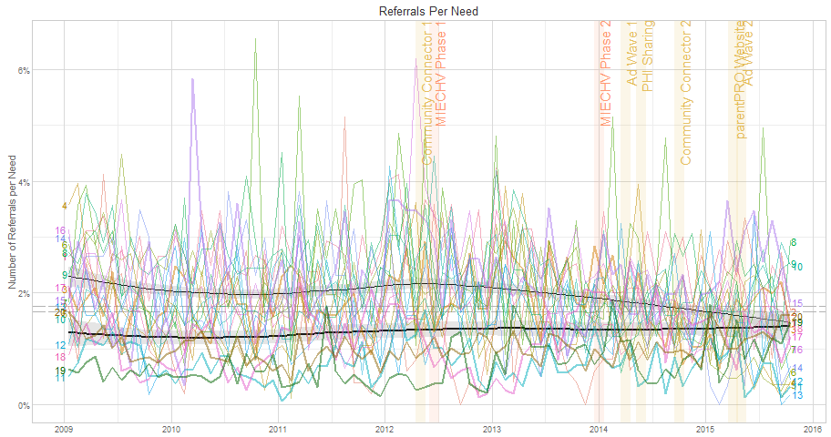

*Response variable*: `ReferralCompleteCount`; *Offset variable*: `InfantNeedCountForTime`

## 3.1 Two Phases of MIECHV –Contracted

```
                  coefficient letter   beta change     p
1                  MiechvEver      a -0.307   0.74 <.001
2                  EraMiechv1      b -0.167   0.85 <.001
3                  EraMiechv2      c -0.191   0.83  .003
4 EraMiechv1:MiechvContracted      d  0.133   1.14 <.001
5 EraMiechv2:MiechvContracted      e  0.229   1.26 <.001
Generalized linear mixed model fit by maximum likelihood (Adaptive Gauss-Hermite Quadrature, nAGQ = 0) ['glmerMod']
 Family: poisson  ( log )
Formula: ReferralCompleteCount ~ 1 + MiechvEver + EraMiechv1 + EraMiechv2 +
    MiechvContracted:EraMiechv1 + MiechvContracted:EraMiechv2 +
    QuarterF + Lag1 + Lag2 + Lag3 + (1 + Lag1 + Lag2 + Lag3 |      RegionID) + offset(log(InfantNeedCountForTime))
   Data: d

     AIC      BIC   logLik deviance df.resid
 11315.1  11545.8  -5614.6  11229.1     1537

Random effects:
 Groups   Name        Variance Std.Dev. Corr
 RegionID (Intercept) 0.095967 0.30979
          Lag1        0.016906 0.13002   0.85
          Lag2        0.006485 0.08053   0.65  0.73
          Lag3        0.001306 0.03613   0.42  0.42 -0.29
Number of obs: 1580, groups:  RegionID, 20

Fixed effects:
                            Estimate Std. Error z value Pr(>|z|)
(Intercept)                 -0.86984    0.08330 -10.442  < 2e-16 ***
MiechvEver                  -0.30679    0.07976  -3.846 0.000120 ***
EraMiechv1                  -0.16673    0.04374  -3.812 0.000138 ***
EraMiechv2                  -0.19077    0.06414  -2.975 0.002935 **
QuarterF2009.3              -0.12930    0.04110  -3.146 0.001656 **
QuarterF2009.4              -0.21794    0.04333  -5.030 4.91e-07 ***
QuarterF2010.1              -0.07599    0.04188  -1.814 0.069640 .
QuarterF2010.2              -0.08194    0.04127  -1.986 0.047082 *
QuarterF2010.3              -0.11409    0.04200  -2.717 0.006597 **
QuarterF2010.4              -0.10526    0.04225  -2.491 0.012730 *
QuarterF2011.1              -0.02070    0.04180  -0.495 0.620462
QuarterF2011.2              -0.02247    0.04096  -0.549 0.583212
QuarterF2011.3              -0.10566    0.04140  -2.552 0.010710 *
QuarterF2011.4              -0.20198    0.04347  -4.646 3.38e-06 ***
```

[output cut: 8 more lines]

```
QuarterF2014.2              -0.01530    0.06366  -0.240 0.810022
QuarterF2014.3               0.01082    0.06406   0.169 0.865897
QuarterF2014.4              -0.08399    0.06464  -1.299 0.193826
QuarterF2015.1               0.02293    0.06388   0.359 0.719620
QuarterF2015.2               0.08033    0.06339   1.267 0.205111
QuarterF2015.3               0.02555    0.06352   0.402 0.687580
Lag1                         0.13642    0.03283   4.155 3.25e-05 ***
Lag2                         0.11806    0.02373   4.975 6.52e-07 ***
Lag3                         0.08000    0.01642   4.871 1.11e-06 ***
EraMiechv1:MiechvContracted  0.13278    0.03073   4.321 1.55e-05 ***
EraMiechv2:MiechvContracted  0.22939    0.03044   7.536 4.86e-14 ***
---
Signif. codes:  0 '***' 0.001 '**' 0.01 '*' 0.05 '.' 0.1 ' ' 1
fit warnings:
fixed-effect model matrix is rank deficient so dropping 2 columns / coefficients
```

## 3.2 Two Phases of MIECHV –Staffed

```
               coefficient letter   beta change     p
1               MiechvEver      a -0.246   0.78  .001
2               EraMiechv1      b -0.133   0.88  .002
3               EraMiechv2      c -0.161   0.85  .012
4 EraMiechv1:MiechvStaffed      d  0.115   1.12 <.001
5 EraMiechv2:MiechvStaffed      e  0.168   1.18 <.001
     AIC      BIC   logLik deviance df.resid
11334.02 11564.72 -5624.01 11248.02  1537.00
```

## 3.3 Event: Community Connector

*Event Description*: Community Connector,Community Connector contracts start. (Tulsa & Oklahoma Counties in May 2012. Garfield, Kay, & Muskogee in October 2014.) - May 01, 2012

```
                    coefficient letter   beta change     p
1                  HasConnector      f  0.116   1.12  .001
2                    MiechvEver      g -0.287   0.75  .001
3                  EraMiechvAll      h -0.161   0.85  .011
4              MiechvContracted      i -0.058   0.94  .139
5 EraMiechvAll:MiechvContracted      j  0.154   1.17 <.001
      AIC       BIC    logLik  deviance  df.resid
11313.698 11549.766 -5612.849 11225.698  1536.000
```

## 3.4 Event: Ad Wave 1

*Event Description*: parentPRO ad campaign in summer and early fall. - Apr 01, 2014

```
                    coefficient letter   beta change     p
1                       AdWave1      f -0.182   0.83 <.001
2                    MiechvEver      g -0.295   0.74 <.001
3                  EraMiechvAll      h -0.174   0.84  .006
4              MiechvContracted      i -0.038   0.96  .330
5 EraMiechvAll:MiechvContracted      j  0.240   1.27 <.001
      AIC       BIC    logLik  deviance  df.resid
11307.208 11543.276 -5609.604 11219.208  1536.000
```

## 3.5 Event: PHI Sharing

*Event Description*: Community Connectors can share PHI more efficiently with parentPRO. - May 23, 2014

```
                    coefficient letter   beta change     p
1                 EraPhiSharing      f  0.061   1.06  .071
2                    MiechvEver      g -0.286   0.75 <.001
3                  EraMiechvAll      h -0.184   0.83  .004
4              MiechvContracted      i -0.037   0.96  .342
5 EraMiechvAll:MiechvContracted      j  0.186   1.20 <.001
      AIC       BIC    logLik  deviance  df.resid
11325.226 11561.294 -5618.613 11237.226  1536.000
```

## 3.6 Event: parentPRO Website

*Event Description*: The state’s umbrella website is deployed. - Apr 02, 2015

```
                    coefficient letter   beta change     p
1                    EraWebsite      f -0.022   0.98  .731
2                    MiechvEver      g -0.292   0.75 <.001
3                  EraMiechvAll      h -0.139   0.87  .002
4              MiechvContracted      i -0.036   0.96  .352
5 EraMiechvAll:MiechvContracted      j  0.208   1.23 <.001
      AIC       BIC    logLik  deviance  df.resid
11322.017 11552.719 -5618.008 11236.017  1537.000
```

## 3.7 Event: Ad Wave 2

*Event Description*: parentPRO ad campaign in late May and some in June. - May 01, 2015

```
                    coefficient letter   beta change     p
1                       AdWave2      f  0.017   1.02  .798
2                    MiechvEver      g -0.293   0.75 <.001
3                  EraMiechvAll      h -0.161   0.85  .011
4              MiechvContracted      i -0.036   0.96  .352
5 EraMiechvAll:MiechvContracted      j  0.208   1.23 <.001
      AIC       BIC    logLik  deviance  df.resid
11323.950 11560.018 -5617.975 11235.950  1536.000
```

# 4 Enrollments

**Two-phase Era**

Model 2’s estimates corresponded very closely to Model 1, suggesting that the two operationalizations of the MIECHV treatment are comparable for completed enrollments.

```
                               MIECHV Contracted     MIECHV Staffed

                                   Change      p         Change      p
                 MiechvEver:   1a    0.64  <.001     2a    0.65  <.001
                 EraMiechv1:   1b    0.72  <.001     2b    0.73  <.001
                 EraMiechv2:   1c    0.74   .008     2c    0.73   .005
EraMiechv1:MiechvContracted:   1d    1.06   .213     2d    1.05   .323
EraMiechv2:MiechvContracted:   1e    1.15   .006     2e    1.18  <.001
```

**Individual Events**

[output not shown]

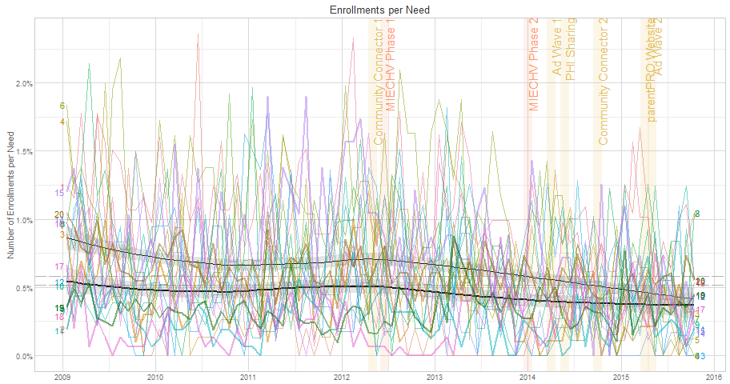

*Response variable*: `EnrollCompletedCount`; *Offset variable*: `InfantNeedCountForTime`

## 4.1 Two Phases of MIECHV –Contracted

```
                  coefficient letter   beta change     p
1                  MiechvEver      a -0.442   0.64 <.001
2                  EraMiechv1      b -0.330   0.72 <.001
3                  EraMiechv2      c -0.299   0.74  .008
4 EraMiechv1:MiechvContracted      d  0.060   1.06  .213
5 EraMiechv2:MiechvContracted      e  0.138   1.15  .006
Generalized linear mixed model fit by maximum likelihood (Adaptive Gauss-Hermite Quadrature, nAGQ = 0) ['glmerMod']
 Family: poisson  ( log )
Formula: EnrollCompletedCount ~ 1 + MiechvEver + EraMiechv1 + EraMiechv2 +
    MiechvContracted:EraMiechv1 + MiechvContracted:EraMiechv2 +
    QuarterF + Lag1 + Lag2 + Lag3 + (1 + Lag1 + Lag2 + Lag3 |      RegionID) + offset(log(InfantNeedCountForTime))
   Data: d

     AIC      BIC   logLik deviance df.resid
  7805.2   8035.9  -3859.6   7719.2     1537

Random effects:
 Groups   Name        Variance  Std.Dev. Corr
 RegionID (Intercept) 1.109e-01 0.333019
          Lag1        1.451e-03 0.038094  0.48
          Lag2        2.971e-03 0.054507  0.86  0.87
          Lag3        4.531e-06 0.002129 -0.71  0.28 -0.24
Number of obs: 1580, groups:  RegionID, 20

Fixed effects:
                             Estimate Std. Error z value Pr(>|z|)
(Intercept)                 -1.952174   0.099872 -19.547  < 2e-16 ***
MiechvEver                  -0.441807   0.110212  -4.009 6.11e-05 ***
EraMiechv1                  -0.330485   0.074773  -4.420 9.88e-06 ***
EraMiechv2                  -0.298773   0.113442  -2.634 0.008446 **
QuarterF2009.3              -0.035306   0.064492  -0.547 0.584069
QuarterF2009.4              -0.216887   0.068473  -3.167 0.001538 **
QuarterF2010.1               0.014158   0.064703   0.219 0.826795
QuarterF2010.2              -0.038155   0.064945  -0.587 0.556870
QuarterF2010.3              -0.185715   0.067638  -2.746 0.006037 **
QuarterF2010.4              -0.137495   0.067424  -2.039 0.041425 *
QuarterF2011.1              -0.067951   0.066522  -1.021 0.307030
QuarterF2011.2              -0.038120   0.065633  -0.581 0.561373
QuarterF2011.3              -0.147285   0.066682  -2.209 0.027191 *
QuarterF2011.4              -0.256016   0.070715  -3.620 0.000294 ***
```

[output cut: 8 more lines]

```
QuarterF2014.2               0.031902   0.113752   0.280 0.779133
QuarterF2014.3               0.072639   0.112995   0.643 0.520319
QuarterF2014.4              -0.298341   0.118249  -2.523 0.011637 *
QuarterF2015.1               0.178614   0.113133   1.579 0.114382
QuarterF2015.2              -0.005951   0.114059  -0.052 0.958391
QuarterF2015.3              -0.028254   0.115217  -0.245 0.806281
Lag1                         0.048546   0.012397   3.916 9.00e-05 ***
Lag2                         0.072419   0.015799   4.584 4.57e-06 ***
Lag3                         0.051253   0.008860   5.785 7.26e-09 ***
EraMiechv1:MiechvContracted  0.060150   0.048272   1.246 0.212743
EraMiechv2:MiechvContracted  0.137849   0.050285   2.741 0.006119 **
---
Signif. codes:  0 '***' 0.001 '**' 0.01 '*' 0.05 '.' 0.1 ' ' 1
fit warnings:
fixed-effect model matrix is rank deficient so dropping 2 columns / coefficients
```

## 4.2 Two Phases of MIECHV –Staffed

```
               coefficient letter   beta change     p
1               MiechvEver      a -0.432   0.65 <.001
2               EraMiechv1      b -0.318   0.73 <.001
3               EraMiechv2      c -0.315   0.73  .005
4 EraMiechv1:MiechvStaffed      d  0.048   1.05  .323
5 EraMiechv2:MiechvStaffed      e  0.168   1.18 <.001
      AIC       BIC    logLik  deviance  df.resid
 7800.254  8030.957 -3857.127  7714.254  1537.000
```

## 4.3 Event: Community Connector

*Event Description*: Community Connector,Community Connector contracts start. (Tulsa & Oklahoma Counties in May 2012. Garfield, Kay, & Muskogee in October 2014.) - May 01, 2012

```
                    coefficient letter   beta change     p
1                  HasConnector      f  0.079   1.08  .188
2                    MiechvEver      g -0.433   0.65 <.001
3                  EraMiechvAll      h -0.279   0.76  .013
4              MiechvContracted      i  0.015   1.02  .807
5 EraMiechvAll:MiechvContracted      j  0.026   1.03  .711
      AIC       BIC    logLik  deviance  df.resid
 7806.982  8043.050 -3859.491  7718.982  1536.000
```

## 4.4 Event: Ad Wave 1

*Event Description*: parentPRO ad campaign in summer and early fall. - Apr 01, 2014

```
                    coefficient letter   beta change     p
1                       AdWave1      f  0.000   1.00  .997
2                    MiechvEver      g -0.448   0.64 <.001
3                  EraMiechvAll      h -0.278   0.76  .013
4              MiechvContracted      i  0.030   1.03  .623
5 EraMiechvAll:MiechvContracted      j  0.074   1.08  .234
      AIC       BIC    logLik  deviance  df.resid
 7808.726  8044.793 -3860.363  7720.726  1536.000
```

## 4.5 Event: PHI Sharing

*Event Description*: Community Connectors can share PHI more efficiently with parentPRO. - May 23, 2014

```
                    coefficient letter   beta change     p
1                 EraPhiSharing      f  0.074   1.08  .204
2                    MiechvEver      g -0.448   0.64 <.001
3                  EraMiechvAll      h -0.305   0.74  .008
4              MiechvContracted      i  0.030   1.03  .617
5 EraMiechvAll:MiechvContracted      j  0.047   1.05  .464
      AIC       BIC    logLik  deviance  df.resid
 7807.123  8043.191 -3859.562  7719.123  1536.000
```

## 4.6 Event: parentPRO Website

*Event Description*: The state’s umbrella website is deployed. - Apr 02, 2015

```
                    coefficient letter   beta change     p
1                    EraWebsite      f -0.175   0.84  .121
2                    MiechvEver      g -0.448   0.64 <.001
3                  EraMiechvAll      h -0.103   0.90  .164
4              MiechvContracted      i  0.030   1.03  .623
5 EraMiechvAll:MiechvContracted      j  0.074   1.08  .225
      AIC       BIC    logLik  deviance  df.resid
 7806.726  8037.428 -3860.363  7720.726  1537.000
```

## 4.7 Event: Ad Wave 2

*Event Description*: parentPRO ad campaign in late May and some in June. - May 01, 2015

```
                    coefficient letter   beta change     p
1                       AdWave2      f  0.027   1.03  .817
2                    MiechvEver      g -0.448   0.64 <.001
3                  EraMiechvAll      h -0.278   0.76  .013
4              MiechvContracted      i  0.030   1.03  .624
5 EraMiechvAll:MiechvContracted      j  0.073   1.08  .234
      AIC       BIC    logLik  deviance  df.resid
 7808.673  8044.741 -3860.336  7720.673  1536.000
```

# 5 Completed Visits Per Need

**Two-phase Era**

Model 2’s estimates corresponded very closely to Model 1, suggesting that the two operationalizations of the MIECHV treatment are comparable for completed visits

```
                               MIECHV Contracted     MIECHV Staffed

                                   Change      p         Change      p
                 MiechvEver:   1a    0.94   .008     2a    0.94   .010
                 EraMiechv1:   1b    0.85  <.001     2b    0.86  <.001
                 EraMiechv2:   1c    0.93   .002     2c    0.92  <.001
EraMiechv1:MiechvContracted:   1d    1.02   .046     2d    1.01   .464
EraMiechv2:MiechvContracted:   1e    1.03   .004     2e    1.05  <.001
```

**Individual Events**

Models 3, 5 and 7 have large *p*-values, suggesting no effect on visits. Model 4 shows a small 4% increase during the first advertising campaign, while Model 6 suggests a slight 4% decrease since the website was deployed. The low correspondence suggested by the models is not surprising. The efforts associated with these five events were intended to boost the referral and enrollment count; affecting the visits was not their goals.

```
          Event  Change      p
3  HasConnector    1.01   .502
4       AdWave1    1.04   .016
5 EraPhiSharing    1.01   .502
6    EraWebsite    0.96   .065
7       AdWave2    0.99   .666
```

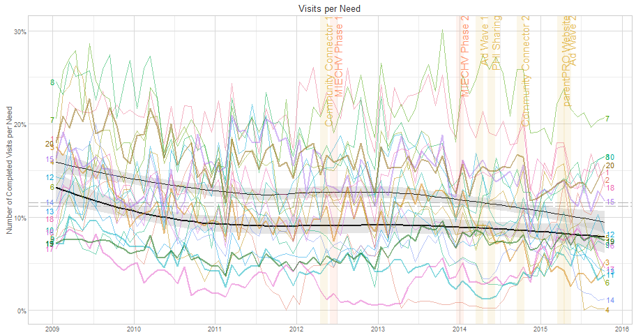

*Response variable*: `VisitCompletedCount`; *Offset variable*: `InfantNeedCountForTime`

## 5.1 Two Phases of MIECHV –Contracted

```
                  coefficient letter   beta change     p
1                  MiechvEver      a -0.064   0.94  .008
2                  EraMiechv1      b -0.160   0.85 <.001
3                  EraMiechv2      c -0.074   0.93  .002
4 EraMiechv1:MiechvContracted      d  0.022   1.02  .046
5 EraMiechv2:MiechvContracted      e  0.032   1.03  .004
Generalized linear mixed model fit by maximum likelihood (Adaptive Gauss-Hermite Quadrature, nAGQ = 0) ['glmerMod']
 Family: poisson  ( log )
Formula: VisitCompletedCount ~ 1 + MiechvEver + EraMiechv1 + EraMiechv2 +
    MiechvContracted:EraMiechv1 + MiechvContracted:EraMiechv2 +
    QuarterF + Lag1 + Lag2 + Lag3 + (1 + Lag1 + Lag2 + Lag3 |      RegionID) + offset(log(InfantNeedCountForTime))
   Data: d

     AIC      BIC   logLik deviance df.resid
 15362.3  15593.0  -7638.2  15276.3     1537

Random effects:
 Groups   Name        Variance Std.Dev. Corr
 RegionID (Intercept) 0.004684 0.06844
          Lag1        0.027243 0.16505  -0.63
          Lag2        0.004136 0.06431   0.25 -0.86
          Lag3        0.014051 0.11854   0.61 -0.99  0.90
Number of obs: 1580, groups:  RegionID, 20

Fixed effects:
                             Estimate Std. Error z value Pr(>|z|)
(Intercept)                  0.120069   0.020770   5.781 7.43e-09 ***
MiechvEver                  -0.064308   0.024201  -2.657 0.007879 **
EraMiechv1                  -0.160353   0.015617 -10.268  < 2e-16 ***
EraMiechv2                  -0.073929   0.023598  -3.133 0.001731 **
QuarterF2009.3              -0.024938   0.013509  -1.846 0.064891 .
QuarterF2009.4              -0.137726   0.014233  -9.677  < 2e-16 ***
QuarterF2010.1               0.021535   0.014142   1.523 0.127828
QuarterF2010.2              -0.088340   0.014160  -6.239 4.41e-10 ***
QuarterF2010.3              -0.048561   0.014568  -3.333 0.000858 ***
QuarterF2010.4              -0.140104   0.015012  -9.332  < 2e-16 ***
QuarterF2011.1              -0.002840   0.015260  -0.186 0.852349
QuarterF2011.2              -0.005096   0.014719  -0.346 0.729197
QuarterF2011.3              -0.065715   0.014633  -4.491 7.10e-06 ***
QuarterF2011.4              -0.149399   0.015218  -9.817  < 2e-16 ***
```

[output cut: 8 more lines]

```
QuarterF2014.2               0.001073   0.023398   0.046 0.963433
QuarterF2014.3               0.008261   0.023428   0.353 0.724385
QuarterF2014.4              -0.089649   0.023653  -3.790 0.000151 ***
QuarterF2015.1               0.043465   0.023555   1.845 0.065007 .
QuarterF2015.2               0.001386   0.023415   0.059 0.952799
QuarterF2015.3              -0.024237   0.023599  -1.027 0.304398
Lag1                         0.386550   0.039531   9.778  < 2e-16 ***
Lag2                         0.308641   0.019765  15.615  < 2e-16 ***
Lag3                         0.140435   0.029345   4.786 1.70e-06 ***
EraMiechv1:MiechvContracted  0.021571   0.010807   1.996 0.045935 *
EraMiechv2:MiechvContracted  0.031882   0.011200   2.847 0.004418 **
---
Signif. codes:  0 '***' 0.001 '**' 0.01 '*' 0.05 '.' 0.1 ' ' 1
fit warnings:
fixed-effect model matrix is rank deficient so dropping 2 columns / coefficients
```

## 5.2 Two Phases of MIECHV –Staffed

```
               coefficient letter   beta change     p
1               MiechvEver      a -0.066   0.94  .010
2               EraMiechv1      b -0.154   0.86 <.001
3               EraMiechv2      c -0.085   0.92 <.001
4 EraMiechv1:MiechvStaffed      d  0.008   1.01  .464
5 EraMiechv2:MiechvStaffed      e  0.048   1.05 <.001
      AIC       BIC    logLik  deviance  df.resid
15350.103 15580.806 -7632.051 15264.103  1537.000
```

## 5.3 Event: Community Connector

*Event Description*: Community Connector,Community Connector contracts start. (Tulsa & Oklahoma Counties in May 2012. Garfield, Kay, & Muskogee in October 2014.) - May 01, 2012

```
                    coefficient letter   beta change     p
1                  HasConnector      f  0.009   1.01  .502
2                    MiechvEver      g -0.062   0.94  .010
3                  EraMiechvAll      h -0.071   0.93  .002
4              MiechvContracted      i -0.001   1.00  .970
5 EraMiechvAll:MiechvContracted      j  0.020   1.02  .217
      AIC       BIC    logLik  deviance  df.resid
15364.497 15600.565 -7638.249 15276.497  1536.000
```

## 5.4 Event: Ad Wave 1

*Event Description*: parentPRO ad campaign in summer and early fall. - Apr 01, 2014

```
                    coefficient letter   beta change     p
1                       AdWave1      f  0.038   1.04  .016
2                    MiechvEver      g -0.063   0.94  .008
3                  EraMiechvAll      h -0.068   0.93  .004
4              MiechvContracted      i  0.001   1.00  .932
5 EraMiechvAll:MiechvContracted      j  0.020   1.02  .163
      AIC       BIC    logLik  deviance  df.resid
15359.137 15595.205 -7635.568 15271.137  1536.000
```

## 5.5 Event: PHI Sharing

*Event Description*: Community Connectors can share PHI more efficiently with parentPRO. - May 23, 2014

```
                    coefficient letter   beta change     p
1                 EraPhiSharing      f  0.008   1.01  .502
2                    MiechvEver      g -0.064   0.94  .008
3                  EraMiechvAll      h -0.074   0.93  .002
4              MiechvContracted      i  0.001   1.00  .923
5 EraMiechvAll:MiechvContracted      j  0.022   1.02  .124
      AIC       BIC    logLik  deviance  df.resid
15364.504 15600.572 -7638.252 15276.504  1536.000
```

## 5.6 Event: parentPRO Website

*Event Description*: The state’s umbrella website is deployed. - Apr 02, 2015

```
                    coefficient letter   beta change     p
1                    EraWebsite      f -0.044   0.96  .065
2                    MiechvEver      g -0.063   0.94  .008
3                  EraMiechvAll      h -0.028   0.97  .095
4              MiechvContracted      i  0.001   1.00  .928
5 EraMiechvAll:MiechvContracted      j  0.025   1.03  .065
      AIC       BIC    logLik  deviance  df.resid
15362.944 15593.647 -7638.472 15276.944  1537.000
```

## 5.7 Event: Ad Wave 2

*Event Description*: parentPRO ad campaign in late May and some in June. - May 01, 2015

```
                    coefficient letter   beta change     p
1                       AdWave2      f -0.011   0.99  .666
2                    MiechvEver      g -0.063   0.94  .009
3                  EraMiechvAll      h -0.071   0.93  .002
4              MiechvContracted      i  0.001   1.00  .928
5 EraMiechvAll:MiechvContracted      j  0.026   1.03  .061
     AIC      BIC   logLik deviance df.resid
15364.76 15600.83 -7638.38 15276.76  1536.00
```

# 6 Completed Visits Per Enrollment

The second visit outcome is *visits per enrollment*, which exhibited a different pattern than the previous three outcomes. *Visits per enrollment* can be interpreted as a type of efficiency: after a client has been enrolled, is the nurse able to sustain the number of visits?

**Two-phase Era**

Coefficients *1c* and *1e* are close to 1.00 and nonsignificant, which suggests there was no difference (c) between Phase 2 and the pre-MIECHV phase or (e) between the MIECHV and comparison regions during Phase 2. Model 2’s estimates corresponded very closely to Model 1, suggesting that the two operationalizations of the MIECHV treatment are comparable for suitable referrals.

The number of referrals, enrollments, and visits (per need) increased for MIECHV counties. The declines demonstrated in *1d* possibly suggest it was difficult for MIECHV regions to sustain their visit efficiency *initially*, in response to the increase number of clients receiving serviced. However the gap closed during Phase 2, proposes the MIECHV regions adapted adequately. (This proposal is supported by adding coefficients *1c* and *1e* in the subsequent outcome, *visits per nurse day*. The sum exceeds 1.00, indicating the count of visits per nurse day increases for MIECHV regions during Phase 2.)

```
                               MIECHV Contracted     MIECHV Staffed

                                   Change      p         Change      p
                 MiechvEver:   1a    1.03   .694     2a    1.03   .729
                 EraMiechv1:   1b    1.13  <.001     2b    1.13  <.001
                 EraMiechv2:   1c    0.97   .242     2c    0.96   .117
EraMiechv1:MiechvContracted:   1d    0.94  <.001     2d    0.92  <.001
EraMiechv2:MiechvContracted:   1e    0.99   .219     2e    1.00   .762
```

**Individual Events**

The same caveats for Models 1 and 2 with this outcome apply to Models 3-7. Model 3 indicates a associates the presence of a Community Connector (the urban counties began in May 2012, while the other were October 2014) with a 10% decrease in *visits per enrollment*. However Model 4 associated the first advertising wave (beginning in April 2014) with an 8% increase. Model 6 indicates an 11% increase since the deployment of the state’s website (in April 2015). Models 5 and 7 provide no evidence of a correspondence between the outcome and either PHI sharing (May 2014) or the second advertising campaign (Summer 2015). The correspondence with the outcome is more likely driven by how the events affect the count of completed enrollments (ie, the ratio’s denominator), as opposed to the count of completed visits (ie, the ratio’s numerator).

```
          Event  Change      p
3  HasConnector    0.90  <.001
4       AdWave1    1.08  <.001
5 EraPhiSharing    1.02   .123
6    EraWebsite    1.11  <.001
7       AdWave2    0.97   .212
```

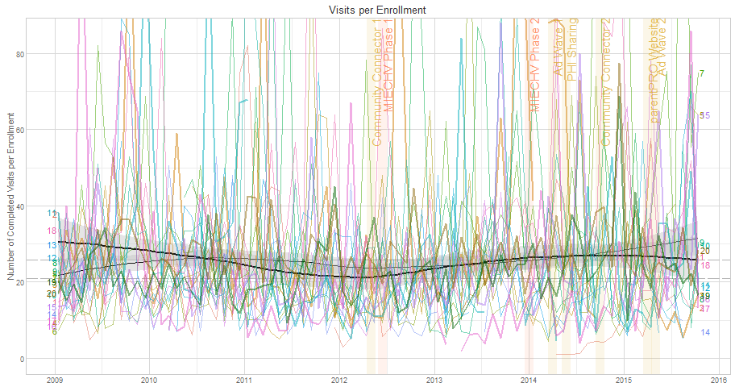

*Response variable*: `VisitCompletedCount`; *Offset variable*: `EnrollCompletedCount`

## 6.1 Two Phases of MIECHV –Contracted

```
                  coefficient letter   beta change     p
1                  MiechvEver      a  0.029   1.03  .694
2                  EraMiechv1      b  0.124   1.13 <.001
3                  EraMiechv2      c -0.028   0.97  .242
4 EraMiechv1:MiechvContracted      d -0.063   0.94 <.001
5 EraMiechv2:MiechvContracted      e -0.013   0.99  .219
Generalized linear mixed model fit by maximum likelihood (Adaptive Gauss-Hermite Quadrature, nAGQ = 0) ['glmerMod']
 Family: poisson  ( log )
Formula: VisitCompletedCount ~ 1 + MiechvEver + EraMiechv1 + EraMiechv2 +
    MiechvContracted:EraMiechv1 + MiechvContracted:EraMiechv2 +
    QuarterF + Lag1 + Lag2 + Lag3 + (1 + Lag1 + Lag2 + Lag3 |      RegionID) + offset(log(EnrollCompletedCount))
   Data: d

     AIC      BIC   logLik deviance df.resid
 56888.3  57119.0 -28401.2  56802.3     1537

Random effects:
 Groups   Name        Variance Std.Dev. Corr
 RegionID (Intercept) 0.61742  0.7858
          Lag1        0.02033  0.1426   -0.86
          Lag2        0.01457  0.1207   -0.55  0.23
          Lag3        0.01105  0.1051   -0.45  0.31 -0.20
Number of obs: 1580, groups:  RegionID, 20

Fixed effects:
                             Estimate Std. Error z value Pr(>|z|)
(Intercept)                  2.421016   0.178530  13.561  < 2e-16 ***
MiechvEver                   0.028798   0.073306   0.393 0.694439
EraMiechv1                   0.124280   0.015825   7.854 4.04e-15 ***
EraMiechv2                  -0.027757   0.023743  -1.169 0.242383
QuarterF2009.3               0.041363   0.013772   3.004 0.002669 **
QuarterF2009.4               0.087230   0.014672   5.945 2.76e-09 ***
QuarterF2010.1              -0.107495   0.014195  -7.573 3.65e-14 ***
QuarterF2010.2              -0.099896   0.014195  -7.037 1.96e-12 ***
QuarterF2010.3               0.016438   0.014380   1.143 0.253010
QuarterF2010.4              -0.145305   0.014930  -9.732  < 2e-16 ***
QuarterF2011.1              -0.112021   0.014897  -7.520 5.49e-14 ***
QuarterF2011.2              -0.089371   0.014692  -6.083 1.18e-09 ***
QuarterF2011.3              -0.074138   0.014591  -5.081 3.75e-07 ***
QuarterF2011.4              -0.014741   0.015238  -0.967 0.333369
```

[output cut: 8 more lines]

```
QuarterF2014.2               0.004899   0.023895   0.205 0.837555
QuarterF2014.3               0.005129   0.023845   0.215 0.829700
QuarterF2014.4               0.354612   0.024097  14.716  < 2e-16 ***
QuarterF2015.1              -0.105433   0.024288  -4.341 1.42e-05 ***
QuarterF2015.2               0.056307   0.023825   2.363 0.018109 *
QuarterF2015.3               0.055773   0.023975   2.326 0.020000 *
Lag1                         0.060517   0.032210   1.879 0.060266 .
Lag2                         0.063672   0.027383   2.325 0.020057 *
Lag3                         0.073983   0.023934   3.091 0.001994 **
EraMiechv1:MiechvContracted -0.062683   0.010775  -5.818 5.97e-09 ***
EraMiechv2:MiechvContracted -0.013383   0.010894  -1.229 0.219259
---
Signif. codes:  0 '***' 0.001 '**' 0.01 '*' 0.05 '.' 0.1 ' ' 1
fit warnings:
fixed-effect model matrix is rank deficient so dropping 2 columns / coefficients
```

## 6.2 Two Phases of MIECHV –Staffed

```
               coefficient letter   beta change     p
1               MiechvEver      a  0.026   1.03  .729
2               EraMiechv1      b  0.120   1.13 <.001
3               EraMiechv2      c -0.037   0.96  .117
4 EraMiechv1:MiechvStaffed      d -0.081   0.92 <.001
5 EraMiechv2:MiechvStaffed      e  0.003   1.00  .762
      AIC       BIC    logLik  deviance  df.resid
 56864.37  57095.07 -28389.19  56778.37   1537.00
```

## 6.3 Event: Community Connector

*Event Description*: Community Connector,Community Connector contracts start. (Tulsa & Oklahoma Counties in May 2012. Garfield, Kay, & Muskogee in October 2014.) - May 01, 2012

```
                    coefficient letter   beta change     p
1                  HasConnector      f -0.109   0.90 <.001
2                    MiechvEver      g  0.007   1.01  .930
3                  EraMiechvAll      h -0.014   0.99  .556
4              MiechvContracted      i  0.034   1.03  .016
5 EraMiechvAll:MiechvContracted      j  0.021   1.02  .197
      AIC       BIC    logLik  deviance  df.resid
 56844.99  57081.06 -28378.50  56756.99   1536.00
```

## 6.4 Event: Ad Wave 1

*Event Description*: parentPRO ad campaign in summer and early fall. - Apr 01, 2014

```
                    coefficient letter   beta change     p
1                       AdWave1      f  0.075   1.08 <.001
2                    MiechvEver      g  0.029   1.03  .698
3                  EraMiechvAll      h -0.007   0.99  .764
4              MiechvContracted      i  0.010   1.01  .474
5 EraMiechvAll:MiechvContracted      j -0.059   0.94 <.001
      AIC       BIC    logLik  deviance  df.resid
 56881.37  57117.44 -28396.68  56793.37   1536.00
```

## 6.5 Event: PHI Sharing

*Event Description*: Community Connectors can share PHI more efficiently with parentPRO. - May 23, 2014

```
                    coefficient letter   beta change     p
1                 EraPhiSharing      f  0.020   1.02  .123
2                    MiechvEver      g  0.027   1.03  .714
3                  EraMiechvAll      h -0.022   0.98  .368
4              MiechvContracted      i  0.010   1.01  .488
5 EraMiechvAll:MiechvContracted      j -0.053   0.95 <.001
      AIC       BIC    logLik  deviance  df.resid
 56902.11  57138.18 -28407.06  56814.11   1536.00
```

## 6.6 Event: parentPRO Website

*Event Description*: The state’s umbrella website is deployed. - Apr 02, 2015

```
                    coefficient letter   beta change     p
1                    EraWebsite      f  0.109   1.11 <.001
2                    MiechvEver      g  0.027   1.03  .714
3                  EraMiechvAll      h -0.123   0.88 <.001
4              MiechvContracted      i  0.009   1.01  .491
5 EraMiechvAll:MiechvContracted      j -0.046   0.96  .001
      AIC       BIC    logLik  deviance  df.resid
 56902.50  57133.20 -28408.25  56816.50   1537.00
```

## 6.7 Event: Ad Wave 2

*Event Description*: parentPRO ad campaign in late May and some in June. - May 01, 2015

```
                    coefficient letter   beta change     p
1                       AdWave2      f -0.031   0.97  .212
2                    MiechvEver      g  0.027   1.03  .717
3                  EraMiechvAll      h -0.016   0.98  .505
4              MiechvContracted      i  0.010   1.01  .490
5 EraMiechvAll:MiechvContracted      j -0.044   0.96  .001
      AIC       BIC    logLik  deviance  df.resid
 56902.94  57139.01 -28407.47  56814.94   1536.00
```

# 7 Completed Visits Per Nurse Day

The final visit outcome is *visits per nurse day*, which can be interpreted as a second perspective on efficiency: for each day a nurse is working, how many visits are being completed? The outcome’s denominator (ie, the region’s count of working days per months) is much more stable than its monthly enrollment count, so the graph’s region trajectories are much calmer compared to *visits per enrollment*; notice the lag 1 coefficient is 6.5 times stronger. As a result, the loess summaries in the graph once again closely agree to the Poisson models.

This outcome is examined during a shorter timeframe than the previous outcomes. June 2012 is the starting point (insted of January 2009) because the OSDH switched to a new “Time & Effort” database system, and the values from before were not directly comparable. The switch occurred roughly at the beginning of Phase 1, so the only time comparison is Phase 1 vs Phase 2; therefore coefficients *1b* and *1d* are not estimated.

**Two-phase Era**

The MIECHV and non-MIECHV regions had comparable levels during Phase 1 (note *1a* is close to 1.00 with a nonsignificant *p*-value). Similarly, *1c* indicates the two phases had similar levels during Phase 1 and Phase 2. However the MIECHV regions had a significantly 4% better productivity than and comparison regions. This is reflected by the gap between the two black loess lines that emerges soon before Phase 2 begins.

It is interesting that the model could detect the significance of a 4% difference with this outcome, when larger differences were not detected for some previous outcomes. This is likely to due to the cleaner *visits per nurse day* signal. When enrollment is in the numerator or denominator of an outcome, the trajectories are much noisier, which weakens power. This hints that *visits per nurse day* is a good candidate for future interventions, including the C1 best practice workshops.

Again Model 2’s estimates corresponded very closely to Model 1, but its coefficients are closer to 1.00. We believe this is because the “staffing” component of Model 2 is partially absorbed by the outcome’s denominator (ie, count of working days).

```
                               MIECHV Contracted     MIECHV Staffed

                                   Change      p         Change      p
                 MiechvEver:   1a    0.97   .245     2a    0.98   .335
                 EraMiechv2:   1c    0.97   .310     2c    0.99   .672
EraMiechv2:MiechvContracted:   1e    1.04   .004     2e    1.01   .269
```

**Individual Events**

Models 4 and 5 indicate small yet significant correspondence between the first marketing campaign and PHI sharing with the outcome. As previously stated, small 3% and 4% differences were better detected with this outcome than noisier ones. The events in the remaining three models were not significant. The internal PHI sharing was not intended primarily to affect visit efficiency, but it’s reasonable to assume that a more streamlined referral and enrollment process provided the nurses with more time to dedicate to visits and servicing clients.

```
          Event  Change      p
3  HasConnector    1.04   .129
4       AdWave1    1.03   .039
5 EraPhiSharing    1.04   .002
6    EraWebsite    0.99   .777
7       AdWave2    0.97   .157
```

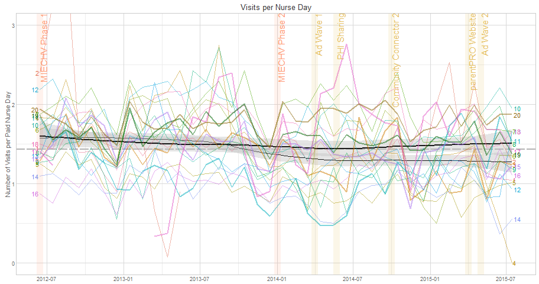

*Response variable*: `VisitCompletedCount`; *Offset variable*: `NurseDayCount`

## 7.1 Two Phases of MIECHV –Contracted

```
                  coefficient letter   beta change     p
1                  MiechvEver      a -0.030   0.97  .245
2                  EraMiechv2      b -0.030   0.97  .310
3 EraMiechv2:MiechvContracted      c  0.042   1.04  .004
Generalized linear mixed model fit by maximum likelihood (Adaptive Gauss-Hermite Quadrature, nAGQ = 0) ['glmerMod']
 Family: poisson  ( log )
Formula: VisitCompletedCount ~ 1 + MiechvEver + +EraMiechv2 + MiechvContracted:EraMiechv2 +
    QuarterF + Lag1 + Lag2 + Lag3 + (1 + Lag1 + Lag2 + Lag3 |      RegionID) + offset(log(NurseDayCount))
   Data: d

     AIC      BIC   logLik deviance df.resid
  6867.8   6995.2  -3405.9   6811.8      672

Random effects:
 Groups   Name        Variance Std.Dev. Corr
 RegionID (Intercept) 0.01500  0.1225
          Lag1        0.02034  0.1426   -0.35
          Lag2        0.01533  0.1238   -0.82 -0.23
          Lag3        0.01139  0.1067   -0.02 -0.73  0.53
Number of obs: 700, groups:  RegionID, 20

Fixed effects:
                              Estimate Std. Error z value Pr(>|z|)
(Intercept)                  0.0882730  0.0369744   2.387  0.01697 *
MiechvEver                  -0.0300610  0.0258613  -1.162  0.24508
EraMiechv2                  -0.0300990  0.0296294  -1.016  0.30970
QuarterF2012.4              -0.0183120  0.0226527  -0.808  0.41887
QuarterF2013.1               0.1624817  0.0226175   7.184 6.78e-13 ***
QuarterF2013.2               0.0877848  0.0222442   3.946 7.93e-05 ***
QuarterF2013.3               0.1073064  0.0221068   4.854 1.21e-06 ***
QuarterF2013.4              -0.0284651  0.0226138  -1.259  0.20812
QuarterF2014.1               0.0935163  0.0237449   3.938 8.20e-05 ***
QuarterF2014.2               0.0889745  0.0238373   3.733  0.00019 ***
QuarterF2014.3               0.0975292  0.0238224   4.094 4.24e-05 ***
QuarterF2014.4               0.0006355  0.0241242   0.026  0.97898
QuarterF2015.1               0.0971060  0.0239349   4.057 4.97e-05 ***
QuarterF2015.2               0.0629170  0.0238633   2.637  0.00838 **
Lag1                         0.3998076  0.0381631  10.476  < 2e-16 ***
Lag2                         0.0955903  0.0354348   2.698  0.00698 **
Lag3                         0.1300935  0.0316987   4.104 4.06e-05 ***
EraMiechv2:MiechvContracted  0.0415914  0.0144998   2.868  0.00413 **
---
Signif. codes:  0 '***' 0.001 '**' 0.01 '*' 0.05 '.' 0.1 ' ' 1
fit warnings:
fixed-effect model matrix is rank deficient so dropping 1 column / coefficient
```

## 7.2 Two Phases of MIECHV –Staffed

```
               coefficient letter   beta change     p
1               MiechvEver      a -0.022   0.98  .335
2               EraMiechv2      b -0.012   0.99  .672
3 EraMiechv2:MiechvStaffed      c  0.014   1.01  .269
      AIC       BIC    logLik  deviance  df.resid
 6874.865  7002.295 -3409.432  6818.865   672.000
```

## 7.3 Event: Community Connector

*Event Description*: Community Connector,Community Connector contracts start. (Tulsa & Oklahoma Counties in May 2012. Garfield, Kay, & Muskogee in October 2014.) - May 01, 2012

```
   coefficient letter   beta change     p
1 HasConnector      f  0.036   1.04  .129
2   MiechvEver      g -0.026   0.97  .324
      AIC       BIC    logLik  deviance  df.resid
 6874.059  7001.489 -3409.029  6818.059   672.000
```

## 7.4 Event: Ad Wave 1

*Event Description*: parentPRO ad campaign in summer and early fall. - Apr 01, 2014

```
  coefficient letter   beta change     p
1     AdWave1      f  0.034   1.03  .039
2  MiechvEver      g -0.021   0.98  .358
      AIC       BIC    logLik  deviance  df.resid
 6871.877  6999.308 -3407.939  6815.877   672.000
```

## 7.5 Event: PHI Sharing

*Event Description*: Community Connectors can share PHI more efficiently with parentPRO. - May 23, 2014

```
    coefficient letter   beta change     p
1 EraPhiSharing      f  0.043   1.04  .002
2    MiechvEver      g -0.028   0.97  .274
      AIC       BIC    logLik  deviance  df.resid
 6866.831  6994.262 -3405.416  6810.831   672.000
```

## 7.6 Event: parentPRO Website

*Event Description*: The state’s umbrella website is deployed. - Apr 02, 2015

```
  coefficient letter   beta change     p
1  EraWebsite      f -0.008   0.99  .777
2  MiechvEver      g -0.017   0.98  .446
      AIC       BIC    logLik  deviance  df.resid
 6874.077  6996.956 -3410.039  6820.077   673.000
```

## 7.7 Event: Ad Wave 2

*Event Description*: parentPRO ad campaign in late May and some in June. - May 01, 2015

```
  coefficient letter   beta change     p
1     AdWave2      f -0.036   0.97  .157
2  MiechvEver      g -0.012   0.99  .596
      AIC       BIC    logLik  deviance  df.resid
 6874.068  7001.499 -3409.034  6818.068   672.000
```

# 8 Time and Effort

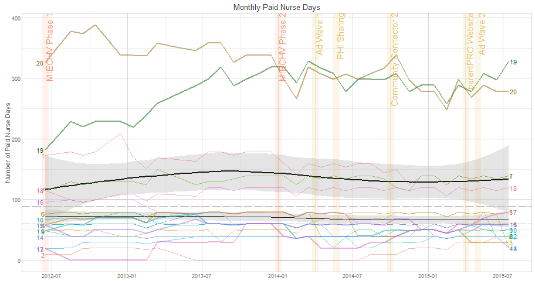

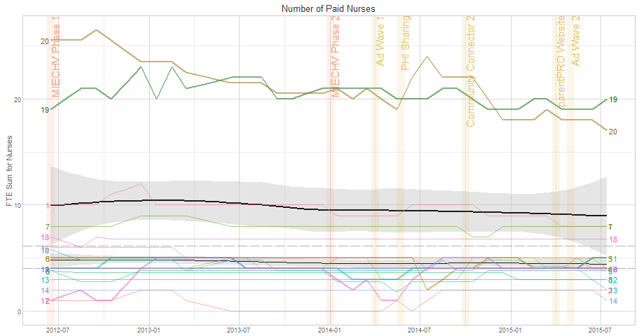

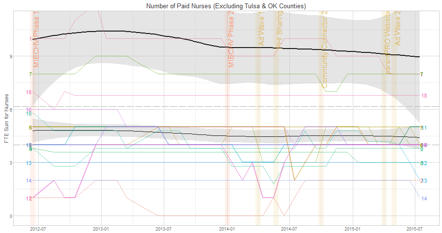

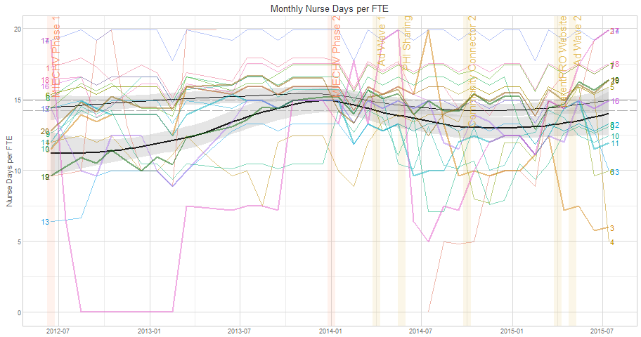

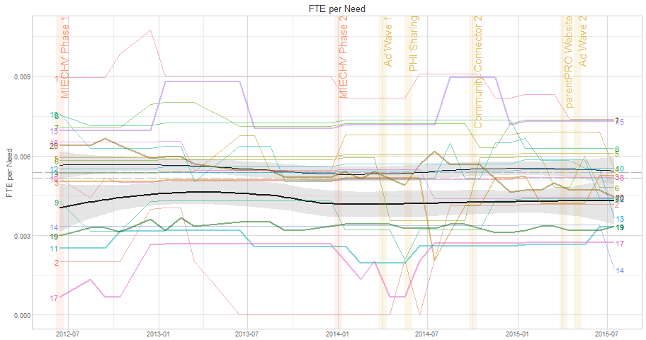

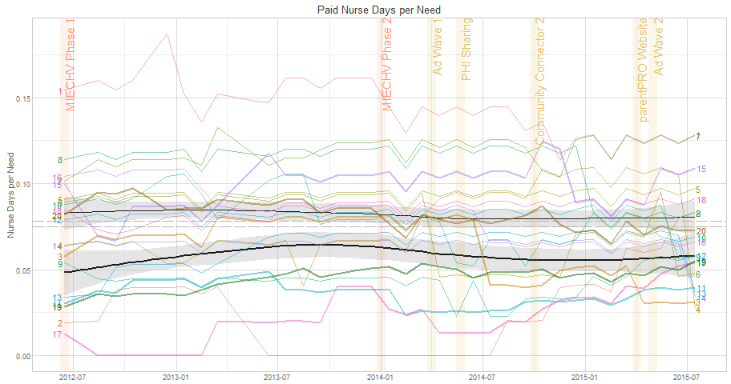

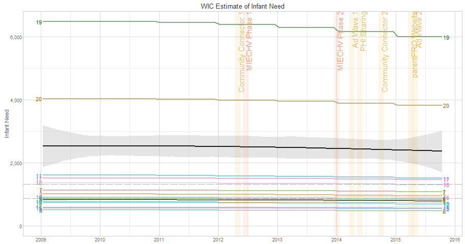

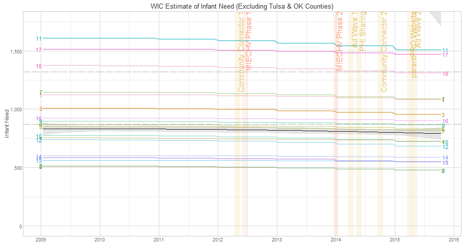

# 9 Region Tables

This table connects a county’s name to its ID, used in the previous scatter plots. The values reflect the whole reporting period (which is 6.8 years long). Regions with at least one MIECHV counties have a bolded ID. Counties not receiving C1 funding are indicated with an asterisk in the second column.

| ID | Counties | Referrals | Enrolls | Visits | Infants in Need |
| --- | --- | --- | --- | --- | --- |
| 1 | Blaine, Creek, Dewey*, Kingfisher, Lincoln, Logan | 2,385 | 948 | 18,569 | 1,112 |
| 2 | Beaver*, Cimarron*, Ellis*, Harper*, Texas, Woods*, Woodward | 655 | 199 | 2,952 | 498 |
| **3** | **Kay, Noble*, Pawnee, Payne** | 1,506 | 343 | 8,039 | 989 |
| 4 | Atoka, Coal, Pittsburg, Pontotoc | 1,005 | 380 | 6,748 | 744 |
| 5 | Nowata*, Osage*, Rogers, Washington | 1,157 | 380 | 7,289 | 840 |
| 6 | Bryan, Choctaw, McCurtain, Pushmataha* | 1,480 | 707 | 9,510 | 856 |
| 7 | Cleveland, McClain* | 2,168 | 665 | 19,985 | 1,126 |
| 8 | Latimer*, Le Flore | 905 | 292 | 7,509 | 501 |
| 9 | Garvin, Grady, Murray, Stephens | 1,741 | 315 | 5,471 | 887 |
| 10 | Canadian, Custer, Washita* | 1,208 | 357 | 8,007 | 757 |
| **11** | **Adair, Muskogee, Sequoyah, Wagoner** | 959 | 346 | 6,617 | 1,573 |
| 12 | Carter, Jefferson*, Johnston, Love*, Marshall | 1,056 | 450 | 8,350 | 719 |
| 13 | Haskell*, McIntosh, Okmulgee | 718 | 199 | 3,559 | 559 |
| 14 | Beckham, Greer*, Harmon*, Jackson, Roger Mills*, Tillman* | 937 | 257 | 4,071 | 598 |
| **15** | **Alfalfa*, Garfield, Grant*, Major*** | 1,076 | 371 | 6,995 | 570 |
| 16 | Hughes, Okfuskee*, Pottawatomie, Seminole | 1,653 | 420 | 7,442 | 918 |
| **17** | **Caddo, Comanche, Cotton*, Kiowa*** | 1,486 | 336 | 5,049 | 1,498 |
| 18 | Cherokee, Craig, Delaware, Mayes, Ottawa | 1,800 | 592 | 15,912 | 1,352 |
| **19** | **Oklahoma** | 3,838 | 1,761 | 35,005 | 6,309 |
| **20** | **Tulsa** | 3,310 | 2,025 | 53,246 | 3,958 |

# 10 Session Information

We would like to address any questions or suggestions during any stage of the evaluation. Please contact David Bard, Will Beasley, or Thomas Wilson.

For the sake of documentation and reproducibility, the current report was rendered on a system using the following software.

```
Report rendered by Will at 2016-01-15, 15:07 -0600
```